# Lab 1 review - Linear Regression

### 4) Data Cleaning and Preprocessing:

#### 4.1):

A great way to visualize this is using the sns.barplot function. ** Plot the columns on the x axis and the number of null values on the y axis. This can be done with functions titanic_data.columns and titanic_data.isnull().sum().

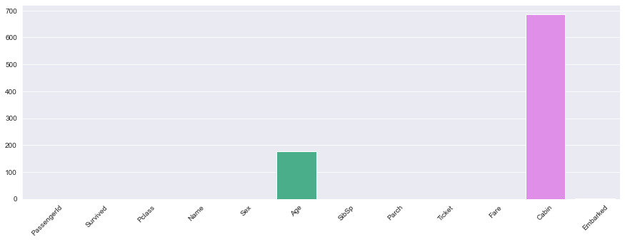

```python
sns.barplot(x=titanic_data.columns,y=titanic_data.isnull().sum().values)
plt.xticks(rotation = 45)
plt.show()
```

#### 4.2):

From these values we can see that a large number of cabin numbers is missing but only a small amount in age. (Note: there are 891 total Entries). Our solution to the missing variables will be to impute (replace) missing age variables with the mean age of non-missing values. (Note Your average age should be 29 before and after you do this). **Impute null "age" values with the average age. ***Post the graph from above again after imputation to see if you are doing it right.

The graph should look as below.

```python
mean_age = int(titanic_data["Age"].mean())
titanic_data["Age"] = titanic_data["Age"].apply(lambda age: mean_age if pd.isnull(age) else age)
```

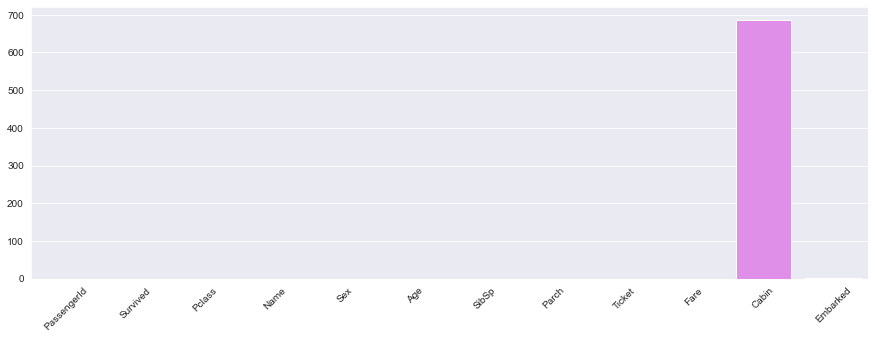

```python
sns.barplot(x=titanic_data.columns,y=titanic_data.isnull().sum().values)
plt.xticks(rotation = 45)
plt.show()
```

#### 4.3):

Next since, as discussed earlier, there isn't enough cabin values to impute the cabin value we will want to drop the cabin column.

#### drop the cabin colum from your data using the command "titanic_data.drop(labels=['col_name','col_name'], axis=1, inplace=True)"

```python
titanic_data.info()
```

```
<class 'pandas.core.frame.DataFrame'>
RangeIndex: 891 entries, 0 to 890
Data columns (total 12 columns):
 #   Column       Non-Null Count  Dtype
---  ------       --------------  -----
 0   PassengerId  891 non-null    int64
 1   Survived     891 non-null    int64
 2   Pclass       891 non-null    int64
 3   Name         891 non-null    object
 4   Sex          891 non-null    object
 5   Age          891 non-null    float64
 6   SibSp        891 non-null    int64
 7   Parch        891 non-null    int64
 8   Ticket       891 non-null    object
 9   Fare         891 non-null    float64
 10  Cabin        204 non-null    object
 11  Embarked     889 non-null    object
dtypes: float64(2), int64(5), object(5)
memory usage: 83.7+ KB
```

#### 4.5):

All that remains now are the problems of the variables "sex" and "embarked". We want to transform these into dummy variables. Recall that dummy variables are variables that take the values of 1 or 0 to indicate the absecne or presence of some category.

*** Make the variables "sex" and "embarked" into dummy variables using the command pd.get_dummies to do this. Make sure to set drop_first to True.

Your data should look like the head() command below.

```python
titanic_data  =pd.get_dummies(data= titanic_data, columns=["Sex","Embarked"],drop_first=True)
titanic_data.drop(labels=["Cabin","Name","Ticket"],axis=1, inplace= True)
```

```python
titanic_data.head()
```

|  | PassengerId | Survived | Pclass | Age | SibSp | Parch | Fare | Sex_male | Embarked_Q | Embarked_S |
| --- | --- | --- | --- | --- | --- | --- | --- | --- | --- | --- |
| 0 | 1 | 0 | 3 | 22.0 | 1 | 0 | 7.2500 | 1 | 0 | 1 |
| 1 | 2 | 1 | 1 | 38.0 | 1 | 0 | 71.2833 | 0 | 0 | 0 |
| 2 | 3 | 1 | 3 | 26.0 | 0 | 0 | 7.9250 | 0 | 0 | 1 |
| 3 | 4 | 1 | 1 | 35.0 | 1 | 0 | 53.1000 | 0 | 0 | 1 |
| 4 | 5 | 0 | 3 | 35.0 | 0 | 0 | 8.0500 | 1 | 0 | 1 |

## 5) Building our model and testing.

#### 5.1)

We are finally ready to build our Logistic regression model.

*** First start by spliting the data into X and y where y contains survived and X contains the remaining data after we finsihed cleaning. Use a test_size of around .3 (+-.05) using the command train_test_split

#### 5.2)

**Build the model using the command LogisticRegression(max_iter=1000) and run .fit() on the training data.

```python
from sklearn.model_selection import train_test_split

X = titanic_data.drop("Survived",axis=1)
y = titanic_data["Survived"]
X_train, X_test, y_train, y_test= train_test_split(X,y,test_size = 0.3)
```

```python
from sklearn.linear_model import LogisticRegression

logmodel  = LogisticRegression(max_iter= 1000)
logmodel.fit(X_train, y_train)
```

```
LogisticRegression(max_iter=1000)
```

```python
predictions= logmodel.predict(X_test)
```

#### 5.3)

**run .predict on your model and use the code below to evaluate your model. You should get something close to what I got although I have seen better.

```python
from sklearn.metrics import classification_report
from sklearn.metrics import confusion_matrix

print(classification_report(y_test,predictions))
print(confusion_matrix(y_test,predictions))
```

```
              precision    recall  f1-score   support

           0       0.76      0.81      0.78       164
           1       0.67      0.60      0.63       104

    accuracy                           0.73       268
   macro avg       0.71      0.70      0.71       268
weighted avg       0.72      0.73      0.72       268

[[133  31]
 [ 42  62]]
```